# Trial Generation for fMRI version of OLM task: Code & reasoning

Joern Alexander Quent

12/04/2022

# Aim

The main aim of this document is to generate the .csv file for the Object-Location Memory (OLM) Task but I will also outline and describe the trigonometry behind this process for future reference.

# Placing 6 objects on circle with 60 degree off-set

Getting the points in a coordinate system that correspond to certain degrees is actually pretty easy. The famous rule *Soh Cah Toa* helps to memorise the relationship between hypotenuse (h), adjacent (a) and opposite (o) and sin, cosine and tangent.

$$sin(\theta) = o/h$$
$$cos(\theta) = a/h$$

$$tan(\theta) = o/a$$
Here is a unit circle with a triangle in it to illustrate this relationship.

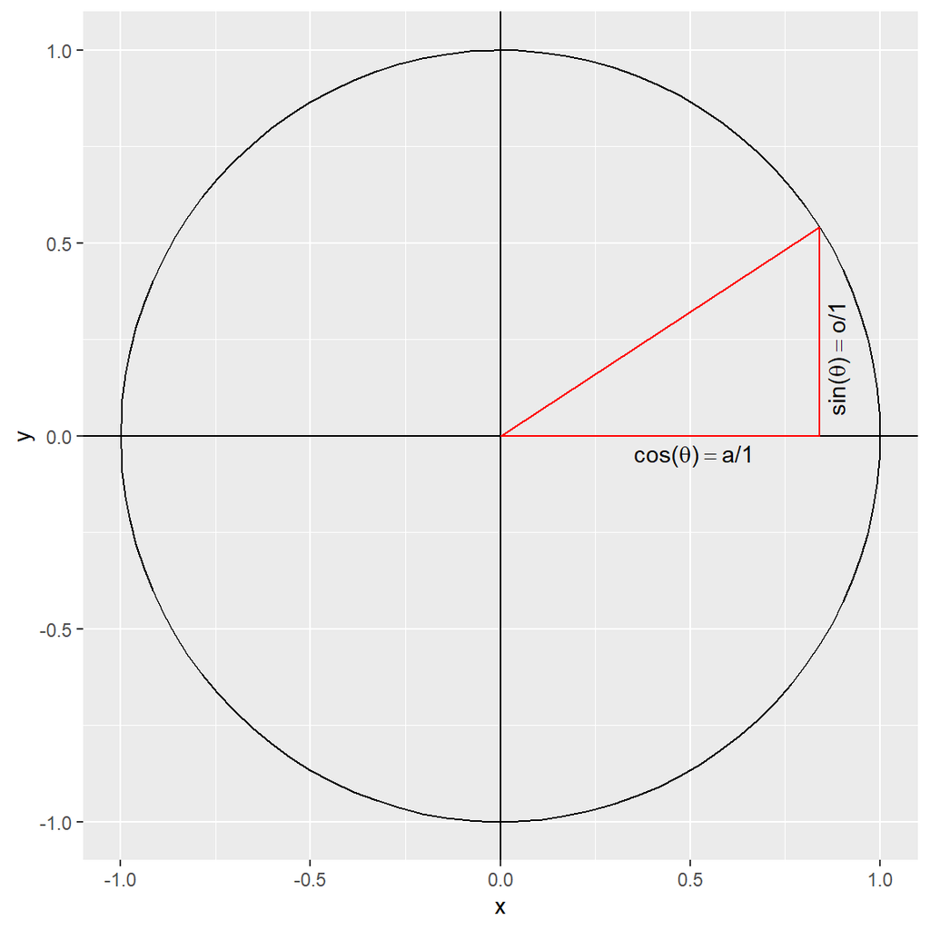

```r
# Create points on unit cirlce
circle   <- circleFun(c(0,-0), 2 ,npoints = 100)

# Take one to draw a triangle
triangle <- data.frame(x = c(0, circle[10, 1], circle[10,1], 0),
                       y = c(0, 0, circle[10, 2], 0))

ggplot(circle, aes(x = x, y = y)) +
  geom_hline(yintercept = 0) +
  geom_vline(xintercept = 0)+
  geom_path() + # Circle
  geom_path(data = triangle, mapping = aes(x = x, y = y), colour = 'red') + # triangle
  annotate('text', x = 0.51, y = -0.05, label = TeX("$cos(\\theta) = a/1$")) +
  annotate('text', x = 0.89, y = 0.2, label = TeX("$sin(\\theta) = o/1$"), angle = 90)
```

We get the angle $\theta$ simply by using the inverse of $tan()$, which is $atan()$, which can be done like this:

```r
theta_radians <- atan(circle[10, 2]/circle[10, 1]) # Will result in angle in radians
theta_degrees <- rad2deg(theta_radians) # which then needs to be transformed to degrees.
theta_degrees
```

```
## [1] 32.72727
```

So to draw 6 objects on circle we only need create a vector with the angles and use $sin()$ & $cos()$ to get the corresponding coordinates. Note from now I will swap the labels that y-axis is now the z-axis as it would be in Unity. In addition to the 6 object locations, there are also 6 so-called start locations that are simply the object locations with a $15^\circ$ offset. Below they are illustrated in red.

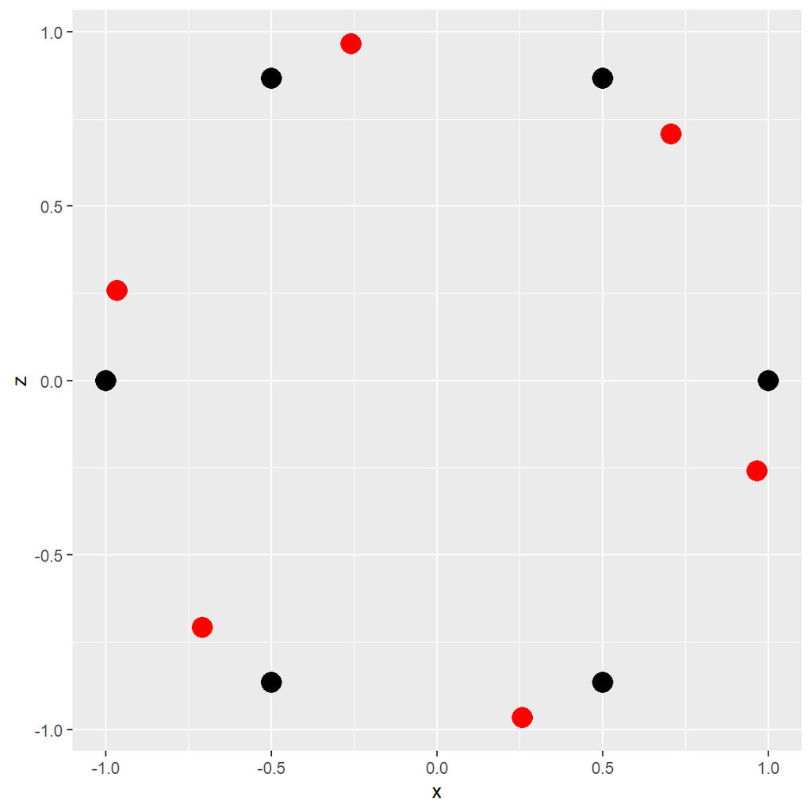

```r
# Start with degrees
object_df <- data.frame(anglesDegrees = seq(60, 360, length.out = 6))

# Convert to radians
object_df$anglesRadians <- deg2rad(object_df$anglesDegrees)

# Use radians to get x and z (because 3D) as it were on unit circle
object_df$x <- cos(object_df$anglesRadians)
object_df$z <- sin(object_df$anglesRadians)
object_df$type <- "object"

# Add the start locations that 15 degrees minus the object locations
start_df <- data.frame(anglesDegrees = object_df$anglesDegrees - 15)
start_df$anglesRadians <- deg2rad(start_df$anglesDegrees)

# Use radians to get x and z (because 3D) as it were on unit circle
start_df$x    <- cos(start_df$anglesRadians)
start_df$z    <- sin(start_df$anglesRadians)
start_df$type <- "start"


ggplot(object_df, aes(x = x, y = z)) +
  geom_point(size = 5) +
  geom_point(data = start_df, mapping = aes(x = x, y = z), size = 5, colour = 'red')
```

In the task, it is planned that one set of starting locations of the participant are other object locations themselves. So each participants will go from each object to every other object. Similarly, participants will go from each start location to every object location but the one that is closest, which gives an extra coverage of angles. To visualise this, let’s get the angles of every possible path when the location of object 1 serves as the starting point. For simplicity, I shifted every point so that Object 1 ends up at (0, 0), and then use same approach as above.

First we need to calculate the angles,

```r
# Recentring
object_df_reCentred <- object_df
object_df_reCentred$x <- object_df_reCentred$x - object_df_reCentred[1, 'x']
object_df_reCentred$z <- object_df_reCentred$z - object_df_reCentred[1, 'z']

# Now calculate all angles
anglesDegree <- c()

# Loop through all options
for(i in 2:6){
  # Step 1 calculate h
  x <- object_df_reCentred[i, 'x']
  z <- object_df_reCentred[i, 'z']

  # Convert radians to degree
  anglesDegree[i - 1] <- getAngleInDegreesFromPoint(x, z)
}
```

which gives us these angles:

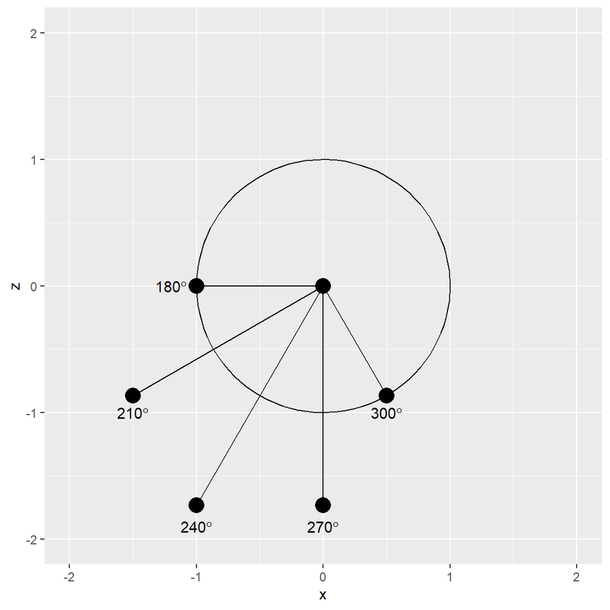

# Calculating all angles that are possible in the task

This is a visualisation of all object 2 object and start location 2 object paths :

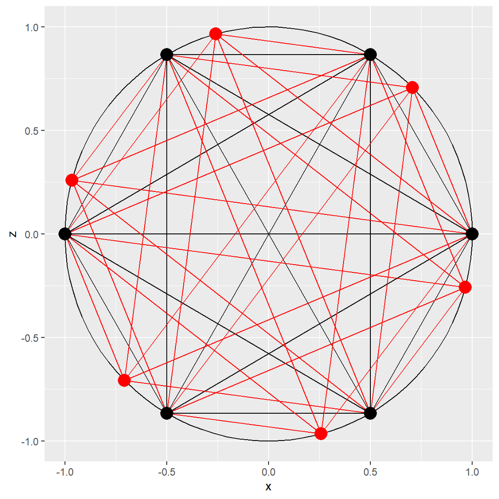

The angles of the paths from Object 1 to all other objects were already calculated in the step above, so now I will just repeat this step for Object 2 - 6 plus for the offset starting points.

```r
# All objects
allObjects <- 1:6

# Loop through all the remaining object 2 object paths
for(j in 2:6){
    # Recentring
  object_df_reCentred   <- object_df
  object_df_reCentred$x <- object_df_reCentred$x - object_df_reCentred[j, 'x']
  object_df_reCentred$z <- object_df_reCentred$z - object_df_reCentred[j, 'z']

  # Now calculate all angles
  tempAnglesDegree <- c()
  index <- 1

  # Remove seed objects
  targetObjects <- allObjects[allObjects != j]

  # Loop through all options
  for(i in targetObjects){
    # Step 1 calculate h
    x <- object_df_reCentred[i, 'x']
    z <- object_df_reCentred[i, 'z']

    # Convert radians to degree
    tempAnglesDegree[index] <- getAngleInDegreesFromPoint(x, z)
    index <- index + 1
  }
  # Add to existing angles
  anglesDegree <- c(anglesDegree, tempAnglesDegree)
}

# Now do the same for the offset start locations
# But now it has to be recentred based on the start locations not the object locations
for(j in 1:6){
  # Recentring
  object_df_reCentred   <- object_df
  object_df_reCentred$x <- object_df_reCentred$x - start_df[j, 'x']
  object_df_reCentred$z <- object_df_reCentred$z - start_df[j, 'z']

  # Now calculate all angles
  tempAnglesDegree <- c()
  index <- 1

  # Remove seed objects
  targetObjects <- allObjects[allObjects != j]

  # Loop through all options
  for(i in targetObjects){
    # Step 1 calculate h
    x <- object_df_reCentred[i, 'x']
    z <- object_df_reCentred[i, 'z']

    # Convert radians to degree
    tempAnglesDegree[index] <- getAngleInDegreesFromPoint(x, z)
    index <- index + 1
  }
  # Add to existing angles
  anglesDegree <- c(anglesDegree, tempAnglesDegree)
}
```

After calculating all angles, I can now plot their distribution in a polar histogram.

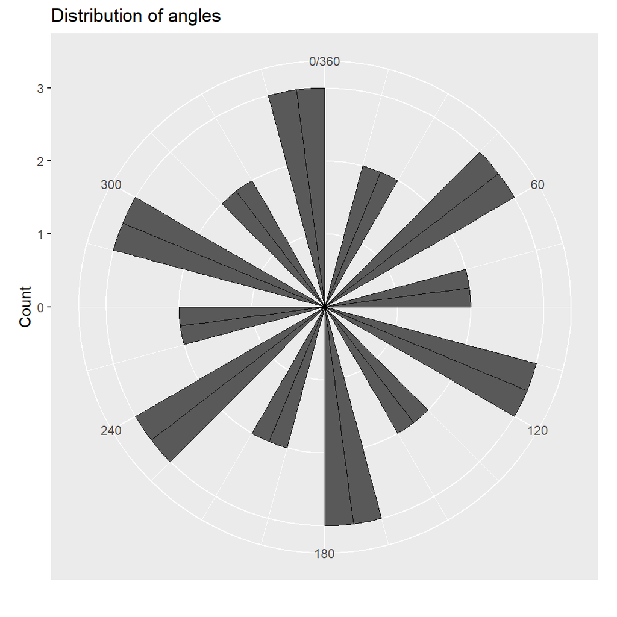

Note to myself: There was one instance where the result was $450^\circ$ instead of $90^\circ$, which I just replaced to make this polar histogram. No idea why that is.

# Generating the input .csv for the task

The .csv that is need for both the practice as well as the fMRI version of task needs entries the following columns:

- *block_num* = Number of the block (needed for UXF).
- *targets* = The target given as the object number from 1 - 13 (see below how these numbers correspond to the object names).
- *start_x* = Start location of the player.
- *start_z* = Start location of the player.
- *start_yRotation* = Start rotation of the player.
- *object_x* = Object location of the target. With the exception of control trials, this must be the same for all trials with the same target.
- *object_z* = Object location of the target. With the exception of control trials, this must be the same for all trials with the same target.
- *cue* = Period the cue is presented in seconds.
- *delay* = Delay period after the cue was presented in seconds.
- *ITI* = ITI in seconds.
- *trialType* = Trial type i.e. standard or control trials using the gift as the object.
- *speedForward* = Forward speed in vm/s.
- *rotationSpeed* = Rotation speed in degrees/s.
- *messageToDisplay* = Integer indicating whether a messages should be displayed after the trial (yes if >= 0, no if -1). Numbers above -1 are used as the index of the message from the list.

## The objects

| Object | Number | Version |
| --- | --- | --- |
| Drum | 7 | Practice |
| Basketball | 2 | Practice |
| Pineapple | 12 | Practice |
| Dice | 5 | Practice |
| Cake | 3 | Practice |
| Lamp | 10 | Practice |
| Barrel | 1 | fMRI |
| Football | 8 | fMRI |
| Pawn | 11 | fMRI |
| Traffic cone | 4 | fMRI |
| Donut | 6 | fMRI |
| Vase | 13 | fMRI |
| Gift | 9 | control |

## The seed for this randomisation

```r
set.seed(20220413)
```

## General task parameters

In the following are general parameters that are the same across all parts of the experiment. The initial orientation (i.e. heading direction) in each trial will be randomly selected from a uniform distribution from 0 to 360.

```r
speedForward  <- 15 # vm/s
rotationSpeed <- 50 # degrees/s
spawnRadius <- 60 # Radius of the circle for spawning the object in the environment
```

## Practice II (Desert square)

### Experimental Design

```r
startDegree <- 15 # Generate object coordinates (360/(number of objects) degree offset starting at 15 degree)
```

Generating the sequence and the location:

```r
# Get objects
practiceObjects <- tab1[tab1$Version == 'Practice', ]

# Get trial numbers etc.
numOfObjects  <- nrow(practiceObjects)

# Convoluted way of generating a sequence starting at startDegree then go in regular steps around a circle
practiceLocations <- data.frame(anglesDegrees = 0:(numOfObjects-1)*(360/numOfObjects) + startDegree)

# Convert to radians
practiceLocations$anglesRadians <- deg2rad(practiceLocations$anglesDegrees)

# Use radians to get x and z (because 3D so it is not y) and multiply with spawnRadius
practiceLocations$x <- spawnRadius * cos(practiceLocations$anglesRadians)
practiceLocations$z <- spawnRadius * sin(practiceLocations$anglesRadians)

# Assign the object to these locations
practiceLocations$targets <- practiceObjects$Number

# Create the sequence of targets
encodingPhase  <- rbind(practiceLocations, practiceLocations) # Repeat each object twice
encodingPhase  <- encodingPhase[sample(1:nrow(encodingPhase)), ] # Shuffle
retrievalPhase <- encodingPhase[sample(1:nrow(encodingPhase)), ] # shuffle again to generate retrieval

# Select starting locations
startLocations <- encodingPhase

# Shuffle run 1
startLocations <- startLocations[sample(1:nrow(startLocations)),]

# Check if there is case where the start location is the same as the object location
while(any(startLocations$targets == encodingPhase$targets)){
  startLocations <- startLocations[sample(1:nrow(startLocations)),]
}

# Assign to the data.frame
encodingPhase$start_x <- startLocations$x
encodingPhase$start_z <- startLocations$z

# Repeat for retrieval
# Shuffle run 1
startLocations <- startLocations[sample(1:nrow(startLocations)),]

# Check if there is case where the start location is the same as the object location
while(any(startLocations$targets == retrievalPhase$targets)){
  startLocations <- startLocations[sample(1:nrow(startLocations)),]
}

# Assign to the data.frame
retrievalPhase$start_x <- startLocations$x
retrievalPhase$start_z <- startLocations$z
```

### Timings

- Encoding phase:
  - Cue Phase (2 s)
  - Delay Phase (1-2 s)
  - Collect Phase (participant determined ~6 s)
  - ITI Phase (1-2 s)
- Retrieval phase:
  - Cue Phase (2 s)
  - Delay Phase (1-2 s)
  - Replace Phase (participant determined ~6 s)
  - Feedback & Collect Phase (participant determined ~6 s)
  - ITI Phase (1-2 s)

```r
cuePeriod   <- 2 # seconds
delayPeriods <- seq(from = 1, to = 2, length.out = 3) # 1 1.5 & 2
ITIPeriods   <- seq(from = 1, to = 2, length.out = 3) # 1 1.5 & 2

# Now shuffle and these timings to the data frame.
# Encoding
encodingPhase$cue   <- cuePeriod
encodingPhase$delay <- sample(rep(delayPeriods, each = 4))
encodingPhase$ITI   <- sample(rep(ITIPeriods, each = 4))
# Retrieval
retrievalPhase$cue   <- cuePeriod
retrievalPhase$delay <- sample(rep(delayPeriods, each = 4))
retrievalPhase$ITI   <- sample(rep(ITIPeriods, each = 4))
```

```r
# Get the control objects
controlObject <- tab1[tab1$Version == 'control', 'Number']

# Get the object location from run 1
objectLocations <- ddply(encodingPhase, c('targets'), summarise, x = x[1], z = z[1])

# Repeat control trial x 1
controlTrials <- objectLocations

# Now repeat the same process that was used for the encoding trials
# Create the columns
controlTrials$start_x <- NA
controlTrials$start_z <- NA

# Get index objects
indexObjects <- unique(controlTrials$targets)


# Loop through all indexObjects
for(i in indexObjects){
  otherObjects <- indexObjects[!(indexObjects %in% i)] # Get all objects that are not the target
  controlTrials[controlTrials$targets == i, 'start_x'] <- objectLocations[objectLocations$targets %in% otherObjects, 'x'][1] # Select the first
  controlTrials[controlTrials$targets == i, 'start_z'] <- objectLocations[objectLocations$targets %in% otherObjects, 'z'][1] # Select the first
}

# Add timings
controlTrials$cue   <- cuePeriod
controlTrials$delay <- sample(rep(delayPeriods))
controlTrials$ITI   <- sample(rep(ITIPeriods))

# Shuffle
controlTrials <- controlTrials[sample(1:nrow(controlTrials)),]

# Add run
controlTrials$run <- 1

# Replace targets with the control task time
controlTrials$targets <- controlObject
```

### Create .csv file

Now I create the data.frame using the relevant column names that the Unity task needs as input.

```r
# Create data.frame
practice2 <- data.frame(block_num = c(rep(1, nrow(encodingPhase)), rep(2, nrow(retrievalPhase)), rep(3, nrow(controlTrials))),
                        targets   = c(encodingPhase$targets, retrievalPhase$targets, controlTrials$targets),
                        start_x   = c(encodingPhase$start_x, retrievalPhase$start_x, controlTrials$start_x),
                        start_z   = c(encodingPhase$start_z, retrievalPhase$start_z, controlTrials$start_z),
                        #start_yRotation = sample(rep(intital_yRotation, 4)), # sample y rotation
                        object_x = c(encodingPhase$x, retrievalPhase$x, controlTrials$x),
                        object_z = c(encodingPhase$z, retrievalPhase$z, controlTrials$z),
                        cue = c(encodingPhase$cue, retrievalPhase$cue, controlTrials$cue),
                        delay = c(encodingPhase$delay, retrievalPhase$delay, controlTrials$delay),
                        ITI = c(encodingPhase$ITI, retrievalPhase$ITI, controlTrials$ITI),
                        trialType = c(rep('encoding', nrow(encodingPhase)), rep('retrieval', nrow(retrievalPhase)), rep('control', nrow(controlTrials))),
                        speedForward = speedForward,
                        rotationSpeed = rotationSpeed,
                        messageToDisplay = -1)

# Sample start locations from uniform distribution
practice2$start_yRotation <- runif(n = nrow(practice2), min = 0, max = 360)

# Add a message after the encoding block
practice2[12, 'messageToDisplay'] <- 1 # Between retrieval and encoding
practice2[24, 'messageToDisplay'] <- 2 # Before control trials

# Write .csv file
write.csv(x = practice2, file = 'practice.csv', quote = FALSE, row.names = FALSE)
```

## Main task (grassy arena)

### Experimental Design

For **encoding**, each object will be seen 5 times, corresponding to 5 routes (6 objects x 5 trials ~ 6 min) and two runs will be provided. Starting positions will be shifted by 15 degrees between the two runs, while the object locations will remain the same.

For **retrieval**, each object will be cued 5 times, corresponding to 5 routes (6 objects x 5 trials ~ 6 min) and two runs will be provided. Starting positions will be shifted by 15 degrees between the runs, while the object locations will remain the same.

There will be as many control trials as there will be retrieval trials, which will be interleaved so that there are always 15 trials of one type in a row.

```r
startDegree <- 60 # Generate object coordinates (360/(number of objects) degree offset starting at 60 degree)
repetitionPerObject <- 5 # How often (per run) should the object be repeated?
```

Generating the sequence and the location:

```r
# Start with run 1
# Get objects
mainTaskObjects <- tab1[tab1$Version == 'fMRI', ]

# Get trial numbers etc.
numOfObjects  <- nrow(mainTaskObjects)

# Convoluted way of generating a sequence starting at startDegree then go in regular steps around a circle
mainTask_locations <- data.frame(anglesDegrees = 0:(numOfObjects-1)*(360/numOfObjects) + startDegree)

# Convert to radians
mainTask_locations$anglesRadians <- deg2rad(mainTask_locations$anglesDegrees)

# Use radians to get x and z (because 3D so it is not y) and multiply with spawnRadius
mainTask_locations$x <- spawnRadius * cos(mainTask_locations$anglesRadians)
mainTask_locations$z <- spawnRadius * sin(mainTask_locations$anglesRadians)

# Assign the object to these locations
mainTask_locations$targets <- mainTaskObjects$Number

# Create the sequence of targets
encodingPhase_run1 <- do.call("rbind", replicate(repetitionPerObject, mainTask_locations, simplify = FALSE)) # Repeat each object x times

# Save locations in temp variable
startLocations <- encodingPhase_run1

# Reduce startLocations to one instance per target
startLocations <- ddply(startLocations, c('targets'), summarise, x = x[1], z = z[1])

# Select five locations that are not the target locations
indexObjects <- unique(encodingPhase_run1$targets) # Get all unique objects

# Create the columns
encodingPhase_run1$start_x <- NA
encodingPhase_run1$start_z <- NA

# Loop through all indexObjects
for(i in indexObjects){
  otherObjects <- indexObjects[!(indexObjects %in% i)] # Get all objects that are not the target
  encodingPhase_run1[encodingPhase_run1$targets == i, 'start_x'] <- startLocations[startLocations$targets %in% otherObjects, 'x']
  encodingPhase_run1[encodingPhase_run1$targets == i, 'start_z'] <- startLocations[startLocations$targets %in% otherObjects, 'z']
}

# Copy for retrieval
retrievalPhase_run1 <- encodingPhase_run1

# Shuffle
encodingPhase_run1  <- encodingPhase_run1[sample(1:nrow(encodingPhase_run1)), ] # Shuffle
retrievalPhase_run1 <- encodingPhase_run1[sample(1:nrow(encodingPhase_run1)), ] # shuffle again to generate retrieval
```

For the 2nd run of both the encoding and the retrieval phase, start locations are offset by $15^\circ$, otherwise everything else remains the same.

```r
# Re-use the same locations but offset them by 15 degrees
mainTask_locations <- data.frame(anglesDegrees = 0:(numOfObjects-1)*(360/numOfObjects) + startDegree + 15)

# Convert to radians
mainTask_locations$anglesRadians <- deg2rad(mainTask_locations$anglesDegrees)

# Use radians to get x and z (because 3D so it is not y) and multiply with spawnRadius
mainTask_locations$x <- spawnRadius * cos(mainTask_locations$anglesRadians)
mainTask_locations$z <- spawnRadius * sin(mainTask_locations$anglesRadians)

# Assign the object to these locations
mainTask_locations$targets <- mainTaskObjects$Number

# Save
mainTask_locations_offset <- mainTask_locations

# Copy the sequence of targets from run 1
encodingPhase_run2 <- encodingPhase_run1

# Copy starting locations
startLocations <- encodingPhase_run2

# Reduce startLocations to one instance per target
startLocations <- ddply(mainTask_locations, c('targets'), summarise, x = x[1], z = z[1])

# Select five locations that are not the target locations
indexObjects <- unique(encodingPhase_run2$targets) # Get all unique objects

# Create the columns
encodingPhase_run2$start_x <- NA
encodingPhase_run2$start_z <- NA

# Loop through all indexObjects
for(i in indexObjects){
  otherObjects <- indexObjects[!(indexObjects %in% i)] # Get all objects that are not the target
  encodingPhase_run2[encodingPhase_run2$targets == i, 'start_x'] <- startLocations[startLocations$targets %in% otherObjects, 'x']
  encodingPhase_run2[encodingPhase_run2$targets == i, 'start_z'] <- startLocations[startLocations$targets %in% otherObjects, 'z']
}

# Copy for retrieval
retrievalPhase_run2 <- encodingPhase_run2

# Shuffle
encodingPhase_run2  <- encodingPhase_run2[sample(1:nrow(encodingPhase_run2)), ] # Shuffle
retrievalPhase_run2 <- encodingPhase_run2[sample(1:nrow(encodingPhase_run2)), ] # shuffle again to generate retrieval
```

```r
# Add run information
encodingPhase_run1$run  <- 1
encodingPhase_run2$run  <- 2
retrievalPhase_run1$run <- 1
retrievalPhase_run2$run <- 2

# Bind to df per phase
encodingPhase  <- rbind(encodingPhase_run1, encodingPhase_run2)
retrievalPhase <- rbind(retrievalPhase_run1, retrievalPhase_run2)
```

### Timings

The timings are the same as in during the practice with the exception that I use more jittering (i.e. more steps).

```r
cuePeriod    <- 2 # seconds
delayPeriods <- seq(from = 1, to = 2, length.out = 6)
ITIPeriods   <- seq(from = 1, to = 2, length.out = 6)

# Now shuffle and these timings to the data frame.
# Encoding
encodingPhase$cue   <- cuePeriod
encodingPhase$delay <- sample(rep(delayPeriods, each = 10))
encodingPhase$ITI   <- sample(rep(ITIPeriods, each = 10))
# Retrieval
retrievalPhase$cue   <- cuePeriod
retrievalPhase$delay <- sample(rep(delayPeriods, each = 10))
retrievalPhase$ITI   <- sample(rep(ITIPeriods, each = 10))
```

### Crate & insert the control trials into the retrieval block

```r
# Get the control objects
controlObject <- tab1[tab1$Version == 'control', 'Number']

# Get the object location from run 1
objectLocations <- ddply(encodingPhase, c('targets'), summarise, x = x[1], z = z[1])

# Repeat control trial x times
controlTrials <- do.call("rbind", replicate(repetitionPerObject, objectLocations, simplify = FALSE)) # Repeat each object x times

# Now repeat the same process that was used for the encoding trials
# Create the columns
controlTrials$start_x <- NA
controlTrials$start_z <- NA

# Loop through all indexObjects
for(i in indexObjects){
  otherObjects <- indexObjects[!(indexObjects %in% i)] # Get all objects that are not the target
  controlTrials[controlTrials$targets == i, 'start_x'] <- objectLocations[objectLocations$targets %in% otherObjects, 'x']
  controlTrials[controlTrials$targets == i, 'start_z'] <- objectLocations[objectLocations$targets %in% otherObjects, 'z']
}

# Add timings
controlTrials$cue   <- cuePeriod
controlTrials$delay <- sample(rep(delayPeriods, each = 5))
controlTrials$ITI   <- sample(rep(ITIPeriods, each = 5))

# Shuffle
controlTrials <- controlTrials[sample(1:nrow(controlTrials)),]

# Add run
controlTrials$run <- 1

# Replace targets with the control task time
controlTrials$targets <- controlObject

# Save in controlTrials1
controlTrials1 <- controlTrials
```

And now I repeat this with the $15^\circ$ offset locations.

```r
# Get the control objects
controlObject <- tab1[tab1$Version == 'control', 'Number']

# Get the object location from run 1
objectLocations <- ddply(encodingPhase_run1, c('targets'), summarise, x = x[1], z = z[1])


# Repeat control trial x times
controlTrials <- do.call("rbind", replicate(repetitionPerObject, objectLocations, simplify = FALSE)) # Repeat each object x times

# Now repeat the same process that was used for the encoding trials
# Create the columns
controlTrials$start_x <- NA
controlTrials$start_z <- NA

# Loop through all indexObjects
for(i in indexObjects){
  otherObjects <- indexObjects[!(indexObjects %in% i)] # Get all objects that are not the target
  controlTrials[controlTrials$targets == i, 'start_x'] <- mainTask_locations_offset[mainTask_locations_offset$targets %in% otherObjects, 'x']
  controlTrials[controlTrials$targets == i, 'start_z'] <- mainTask_locations_offset[mainTask_locations_offset$targets %in% otherObjects, 'z']
}

# Add timings
controlTrials$cue   <- cuePeriod
controlTrials$delay <- sample(rep(delayPeriods, each = 5))
controlTrials$ITI   <- sample(rep(ITIPeriods, each = 5))

# Shuffle
controlTrials <- controlTrials[sample(1:nrow(controlTrials)),]

# Add run
controlTrials$run <- 2

# Replace targets with the control task time
controlTrials$targets <- controlObject

# Remove unnecessary
controlTrials$anglesDegrees <- NULL
controlTrials$anglesRadians <- NULL

# Save in controlTrials2 & bind together
controlTrials2 <- controlTrials
controlTrials  <- rbind(controlTrials1, controlTrials2)
```

### Create the .csv file

```r
# Encoding run 1
tempVar <- encodingPhase[encodingPhase$run == 1, ]
encoding1 <- data.frame(block_num = c(rep(1, nrow(tempVar))),
                       run = c(tempVar$run),
                       targets = c(tempVar$targets),
                       start_x = c(tempVar$start_x),
                       start_z = c(tempVar$start_z),
                       object_x = c(tempVar$x),
                       object_z = c(tempVar$z),
                       cue = c(tempVar$cue),
                       delay = c(tempVar$delay),
                       ITI = c(tempVar$ITI),
                       trialType = c(rep('encoding', nrow(tempVar))),
                       speedForward = speedForward,
                       rotationSpeed = rotationSpeed,
                       messageToDisplay = -1)

# Encoding run 2
tempVar <- encodingPhase[encodingPhase$run == 2, ]
encoding2 <- data.frame(block_num = c(rep(3, nrow(tempVar))),
                  run = c(tempVar$run),
                  targets = c(tempVar$targets),
                  start_x = c(tempVar$start_x),
                  start_z = c(tempVar$start_z),
                  object_x = c(tempVar$x),
                  object_z = c(tempVar$z),
                  cue = c(tempVar$cue),
                  delay = c(tempVar$delay),
                  ITI = c(tempVar$ITI),
                  trialType = c(rep('encoding', nrow(tempVar))),
                  speedForward = speedForward,
                  rotationSpeed = rotationSpeed,
                  messageToDisplay = -1)

# Retrieval 1
tempVar <- retrievalPhase[retrievalPhase$run == 1, ]
retrieval1 <- data.frame(block_num = c(rep(1, nrow(tempVar))),
                       run = c(tempVar$run),
                       targets = c(tempVar$targets),
                       start_x = c(tempVar$start_x),
                       start_z = c(tempVar$start_z),
                       object_x = c(tempVar$x),
                       object_z = c(tempVar$z),
                       cue = c(tempVar$cue),
                       delay = c(tempVar$delay),
                       ITI = c(tempVar$ITI),
                       trialType = c(rep('retrieval', nrow(tempVar))),
                       speedForward = speedForward,
                       rotationSpeed = rotationSpeed,
                       messageToDisplay = -1)

# Retrieval 2
tempVar <- retrievalPhase[retrievalPhase$run == 2, ]
retrieval2 <- data.frame(block_num = c(rep(1, nrow(tempVar))),
                       run = c(tempVar$run),
                       targets = c(tempVar$targets),
                       start_x = c(tempVar$start_x),
                       start_z = c(tempVar$start_z),
                       object_x = c(tempVar$x),
                       object_z = c(tempVar$z),
                       cue = c(tempVar$cue),
                       delay = c(tempVar$delay),
                       ITI = c(tempVar$ITI),
                       trialType = c(rep('retrieval', nrow(tempVar))),
                       speedForward = speedForward,
                       rotationSpeed = rotationSpeed,
                       messageToDisplay = -1)

# Control 1
tempVar <- controlTrials[controlTrials$run == 1, ]
control1 <- data.frame(block_num = c(rep(1, nrow(tempVar))),
                       run = c(tempVar$run),
                       targets = c(tempVar$targets),
                       start_x = c(tempVar$start_x),
                       start_z = c(tempVar$start_z),
                       object_x = c(tempVar$x),
                       object_z = c(tempVar$z),
                       cue = c(tempVar$cue),
                       delay = c(tempVar$delay),
                       ITI = c(tempVar$ITI),
                       trialType = c(rep('control', nrow(tempVar))),
                       speedForward = speedForward,
                       rotationSpeed = rotationSpeed,
                       messageToDisplay = -1)
# Control 2
tempVar <- controlTrials[controlTrials$run == 2, ]
control2 <- data.frame(block_num = c(rep(1, nrow(tempVar))),
                       run = c(tempVar$run),
                       targets = c(tempVar$targets),
                       start_x = c(tempVar$start_x),
                       start_z = c(tempVar$start_z),
                       object_x = c(tempVar$x),
                       object_z = c(tempVar$z),
                       cue = c(tempVar$cue),
                       delay = c(tempVar$delay),
                       ITI = c(tempVar$ITI),
                       trialType = c(rep('control', nrow(tempVar))),
                       speedForward = speedForward,
                       rotationSpeed = rotationSpeed,
                       messageToDisplay = -1)

# Add to on df called mainTask
mainTask <- rbind(encoding1, # Encoding 1
                  retrieval1[1:15, ], # retrieval run 1.1
                  control1[1:15, ], # control half 1.1
                  retrieval1[16:30, ], # retrieval run 1.2
                  control1[16:30, ], # control half 1.2
                  encoding2, # Encoding 2
                  retrieval2[1:15, ], # retrieval run 2.1
                  control2[1:15,], # control half 2.1
                  retrieval2[16:30, ], # retrieval run 2.2
                  control2[16:30,]) # control half 2.2

# Sample start locations from uniform distribution
mainTask$start_yRotation <- runif(n = nrow(mainTask), min = 0, max = 360)


# Add a messages after the runs
mainTask[30, 'messageToDisplay']  <- 0 # Before retrieval/control 1
mainTask[90, 'messageToDisplay']  <- 1 # Before encoding 2
mainTask[120, 'messageToDisplay'] <- 0 # Before retrieval/control 2

# Write .csv file
write.csv(x = mainTask, file = 'mainTask.csv', quote = FALSE, row.names = FALSE)
```

### Checks

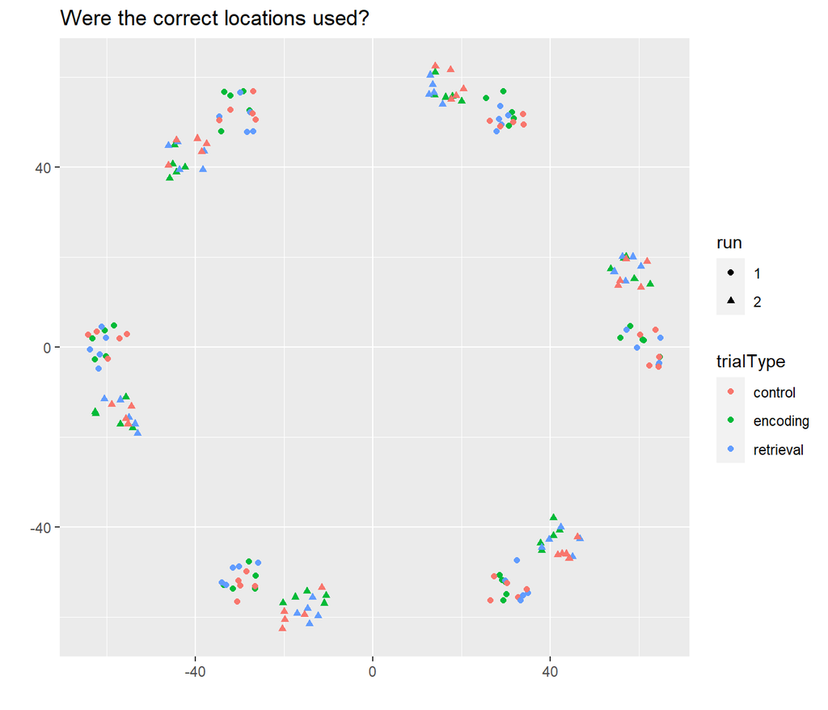

As second test, I check whether all paths are sampled for all three types:

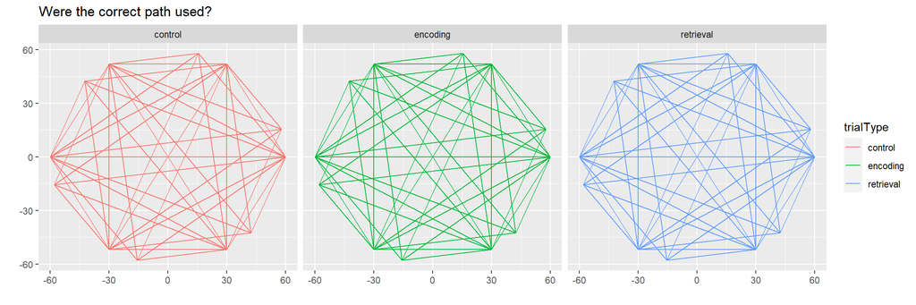

That is case as the patterns created by the paths are the same for all three trial types.